# Project 1

Bailey Young, Sage Young, Matt Ramundo

Friday, April 10, 2020 @ 11:43 AM

### **Data Summary**

#### **Data Summary**

```r
Housing <- read_excel("Housing.xlsx")
#First we check to see if there are any missing values in the data set. Then, we check to see if there are any outliers and investigate them.
!is.na(Housing)
```

[output not shown]

[output cut: 139 more lines]

```r
#There are no missing values in this dataset.
```

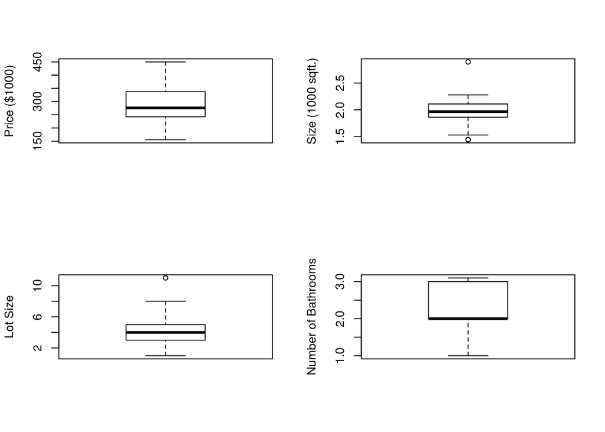

```r
attach(Housing)
# 2x2 of boxplots for each variable to see if there are any unusual values
par(mfrow=c(2,2))
boxplot(price, ylab = "Price ($1000)")
boxplot(size, ylab = "Size (1000 sqft.)")
boxplot(lot, ylab = "Lot Size")
boxplot(bath, ylab = "Number of Bathrooms")
```

```r
#here we use which.min/which.max and min/max functions to find the specific points shown on the boxplot
which.min(size)
```

```
## [1] 20
```

```r
min(size)
```

```
## [1] 1.44
```

```r
which.max(size)
```

```
## [1] 76
```

```r
max(size)
```

```
## [1] 2.896
```

```r
which.max(lot)
```

```
## [1] 74
```

```r
max(lot)
```

```
## [1] 11
```

##### **Missing values:** We see that there are no missing values in the dataset and move on to evaluate the outliers that are shown in the boxplots of each variable.

##### **Outliers:**

- **Price:** Looking at the price boxplot, we see no outliers.
- **Size:** On the size boxplot, we see two outliers: one home with a price much greater, and one home with a price that is much less. Neither of the values for these outliers is unthinkably large or small for the size of a home. They may just be unlikely in this area. Taking a closer look we see that the smaller outlier is #20, with a square footage of 1440. We see that this is an older home, built in 1948, 3 bed, 2 bath, 2 car garage, on the market for 277,000 dollars. We conclude that the house is small, but upon reviewing the values for the other variables, there is nothing too concerning. We decide to leave this point in the dataset. The larger outlier, #76 is 2896 sqft, 5 bed, 3 bath, 2 car garage, built in 1979, and selling for 349,500 dollars. We concluded that 2896 sqft. for a 5 bed, 3 bath, and 2 car garage makes sense. It is the largest home in the area, but the other values don’t suggest anyting alarming. We think that the price looks a little low, but that may be because of the age of the house or it could be in an undesirable location.
- **Lot:** On the lot boxplot, we have one outlier that is greater than the rest. It is #74 and scored an 11 on the lot size ranking scale. Since we don’t have any actual measurements to reference, it is hard to make a solid conclusion as to whether this point is accurate or not. The price of this home is 435,000 dollars, which is one of the most expensive in the set. The house is also fairly big, at 2253 sqft. After looking at the values for #76, the largest home at 2,896 sqft., priced at 349,500, and built in the same year, 1979 we conclude that the values for #74 make sense. The home is smaller, but more expensive, which coincides with the idea that it has a massive lot. Again, we cannot be positve as to whether or not this point has some astronomical value for the lot variable without exact measurements, but all things considered, we think it is fairly in line with the other points, and decide to leave it under the assumption that it is probably a farmhouse or something similar.
- **Bathrooms:** There are no outliers present in the bathrooms boxplot.

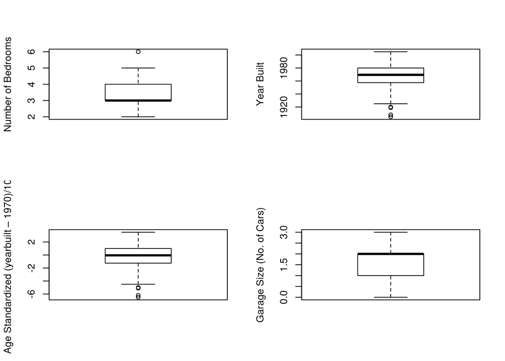

```r
par(mfrow=c(2,2))
boxplot(bedrooms, ylab = "Number of Bedrooms")
boxplot(yearbuilt, ylab = "Year Built")
boxplot(agestandardized, ylab = "Age Standardized (yearbuilt – 1970)/10)")
boxplot(garagesize, ylab = "Garage Size (No. of Cars)")
```

```r
which.max(bedrooms)
```

```
## [1] 35
```

```r
max(bedrooms)
```

```
## [1] 6
```

```r
parker_district <- filter(Housing, elem == "parker")
which.max(parker_district$price)
```

```
## [1] 10
```

```r
#filtering the dataset in order to locate the max price in that district
edge_district <- filter(Housing, elem == "edge")
which.max(edge_district$price)
```

```
## [1] 26
```

```r
#finding the id for outliers in the school district boxplot
```

- **Elementary School District:** There were two outliers when looking at the elementary school districts. One abnormally expesive house in Edge district, and one in Parker. In the Parker Elementary District dataset, we had #10. It is a 2,129 sqft., 3 bed, 2 bath, lot size = 5, built in 2003, and pending sale for 355,000 dollars. All of these numbers fall in line with other homes in the main dataset, but it is quite expensive for something in the Parker Elementary District. It is one of only three homes in the district built after 2000, which we think is the reasoning behind the price. We decide this point is not all that unusual. Point #26 in the Edge Elementary District dataset is the outlier for price within that district. We recognize this as #74 from the main dataset. The reason for the expensive price is the huge lot. It does seem slightly out of place for the Edge District, but we decide that the numbers make sense and it should be kept in.

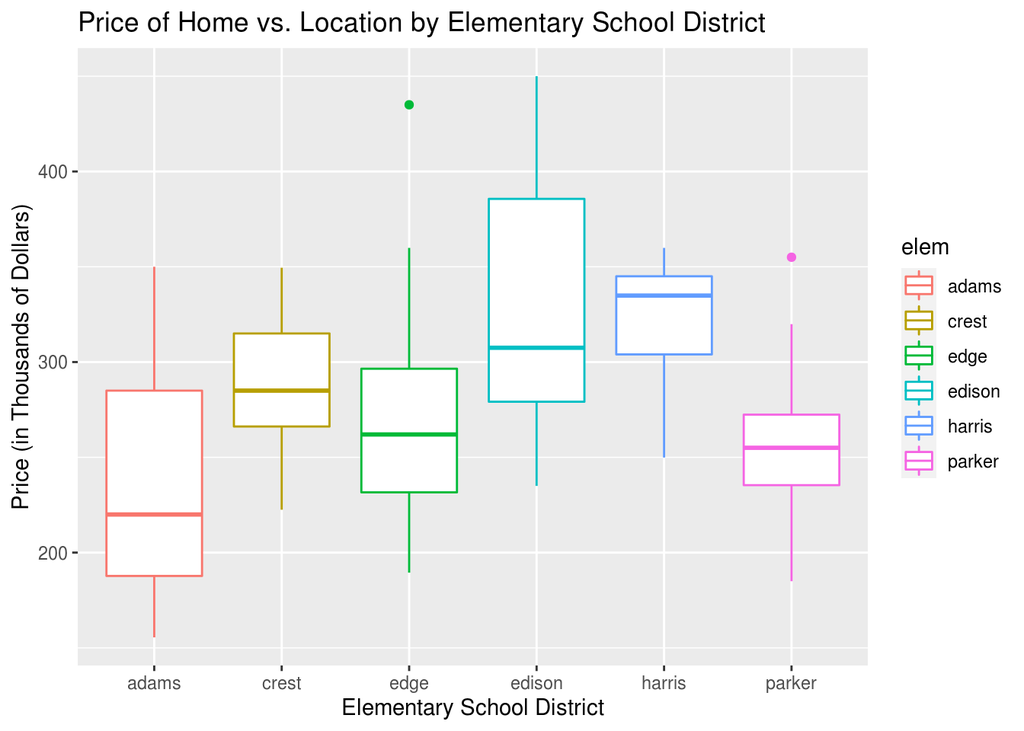

```r
#for the categorical variables we made a boxplot showing price vs. the different categories
ggplot(Housing, aes(x=elem, y=price, color=elem)) +
  geom_boxplot() +
  labs(y = "Price (in Thousands of Dollars)", x = "Elementary School District", title = "Price of Home vs. Location by Elementary School District")
```

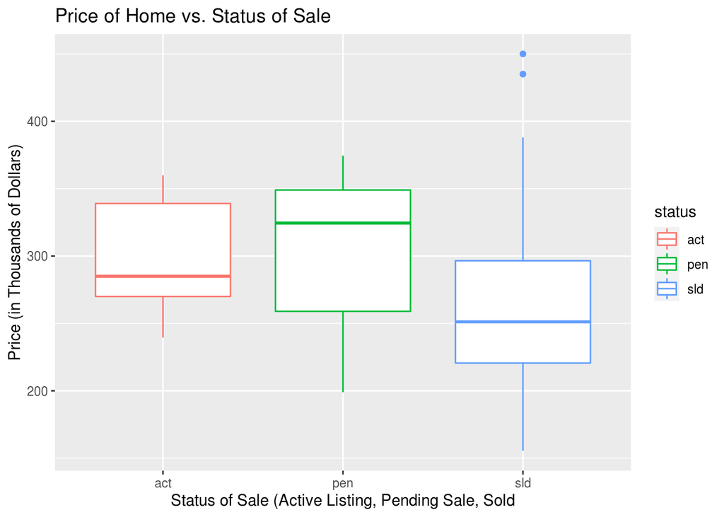

```r
ggplot(Housing, aes(x=status, y=price, color=status)) +
  geom_boxplot() +
  labs(y = "Price (in Thousands of Dollars)", x = "Status of Sale (Active Listing, Pending Sale, Sold", title = "Price of Home vs. Status of Sale" )
```

- **Status:** There are two price outliers for the status boxplot, both are categorized as “sold”. They are #2 and #74. #74 we are very familiar with at this point, but looking at #2 it does seem unusually expensive. #2 is a 4 bed, 3 bath, 2054 sqft., lot size = 5, built in 1957 and selling for 450,000 dollars. We remember there were no outliers in the price boxplot, so the price itself is not abnormal within the dataset. 450,000 dollars is an abnormal price compared to other homes with a sold status. We did not think that status would have very much of an impact on price. The only thing we can think of is that the price that a home sells for may be less than what it was listed for because people tend to negotiate on house prices and the sellers price will go down. Therefore active listing prices may tend to be higher than sold prices. #2 shows the opposite. The status is sold but it is the highest price in the dataset overall. The house is kind of big, but it is older. Since the price is not anything unthinkable, we decide to leave this point in. It is an expensive home, but there is probably some justification. It may have a pool or very expensive renovations.
- **Conclusion:** After reviewing the outliers for each variable, there is only one point we decided to remove, #35. Since we reviewed outliers based on there proximity to other values within the variable, and then looked at the values for other variables for that home to justify including or excluding them, it is possible that we may have overlooked something or perhaps justified something that is more outrageous than it appears from looking at the homes on a case by case basis. This is just a starting point for our model. When we use multiple variables to predict price, we may find more abnormalities or outlies in our data. Therefore, the conclusions made in this section are subject to change.

```r
#removing point #35
Housing1.0 <- Housing[-c(35),]
Housing1.0
```

```
## # A tibble: 75 x 11
##       id price  size   lot  bath bedrooms yearbuilt agestandardized garagesize
##    <dbl> <dbl> <dbl> <dbl> <dbl>    <dbl>     <dbl>           <dbl>      <dbl>
##  1     1  388   2.18     4   3          4      1940            -3            0
##  2     2  450   2.05     5   3          4      1957            -1.3          2
##  3     3  386   2.11     5   2          4      1955            -1.5          2
##  4     4  350   1.44     6   1          2      1956            -1.4          1
##  5     5  156.  1.8      1   2          4      1994             2.4          1
##  6     6  220   1.96     5   2          3      1940            -3            1
##  7     7  240.  1.8      4   1.1        4      1958            -1.2          1
##  8     8  207   2.25     4   2          4      1961            -0.9          2
##  9     9  270.  1.92     4   2.1        4      1965            -0.5          2
## 10    10  239.  1.92     5   2.1        3      1968            -0.2          2
## # … with 65 more rows, and 2 more variables: status <chr>, elem <chr>
```

*Here we remove #35 from the previous dataset (Housing). The dataset we are working with in the next section is Housing1.0, with 75 observations. The points mentioned in this section (data = Housing) by ID will not necessarily line up with the IDs in follwing sections (data = Housing1.0)*

### **Exploratory Data Analysis**

#### **Exploratory Data Analysis**

```r
#First, we were interested to see whether these categorical variables had any significant impact on price
lm_status <- lm(price ~ status, data = Housing1.0)
summary(lm_status)
```

```
##
## Call:
## lm(formula = price ~ status, data = Housing1.0)
##
## Residuals:
##     Min      1Q  Median      3Q     Max
## -114.17  -40.65  -14.66   40.47  180.34
##
## Coefficients:
##             Estimate Std. Error t value Pr(>|t|)
## (Intercept)  301.526     11.827  25.495   <2e-16 ***
## statuspen      2.489     20.220   0.123    0.902
## statussld    -31.861     15.309  -2.081    0.041 *
## ---
## Signif. codes:  0 '***' 0.001 '**' 0.01 '*' 0.05 '.' 0.1 ' ' 1
##
## Residual standard error: 59.13 on 72 degrees of freedom
## Multiple R-squared:  0.07398,    Adjusted R-squared:  0.04826
## F-statistic: 2.876 on 2 and 72 DF,  p-value: 0.06285
```

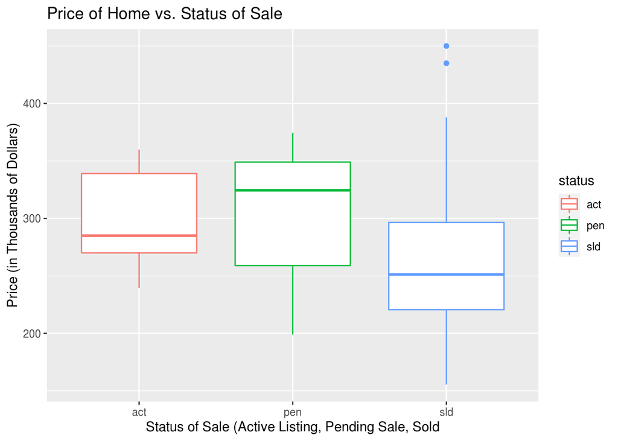

```r
ggplot(Housing, aes(x=status, y=price, color=status)) +
  geom_boxplot() +
  labs(y = "Price (in Thousands of Dollars)", x = "Status of Sale (Active Listing, Pending Sale, Sold", title = "Price of Home vs. Status of Sale" )
```

After modeling price as a function of status, status as a whole seems to be very close to being significant. The p-value is 0.06285 and R-squared is 0.07398. We were correct in our prediction that sold houses would be less expensive than those currently on the market. We were surprised to see that houses pending sale were on average much more expensive than those that had sold. We assumed the prices of houses pending sale and those that were already sold would be very close, but we found that prices of active listings and homes pending sale were much closer. At this point, we were unable to conclude as to whether or not status would be helpful as a predictor in our model.

For a model predicting price only as a function of status, our equation would be:

- X1 = 1 if Pending, 0 if otherwise
- X2 = 1 if Sold, 0 if otherwise

$$\hat{Y} = {301.526} + 2.489 (X_1) - 31.861(X_2)$$

Here, the default is active listing. For an active listing, the price is predicted at 301,526. If the house is pending, we add 2,489 to that price. If the house is sold, we subtract 31,861 from that price.

```r
lm_elem <- lm(price ~ elem, data = Housing1.0)
summary(lm_elem)
```

```
##
## Call:
## lm(formula = price ~ elem, data = Housing1.0)
##
## Residuals:
##     Min      1Q  Median      3Q     Max
## -98.882 -41.102  -2.447  30.269 165.242
##
## Coefficients:
##             Estimate Std. Error t value Pr(>|t|)
## (Intercept)   241.83      31.57   7.659 8.39e-11 ***
## elemcrest      45.98      38.67   1.189   0.2385
## elemedge       27.92      33.35   0.837   0.4052
## elemedison     92.05      35.62   2.584   0.0119 *
## elemharris     77.27      34.79   2.221   0.0296 *
## elemparker     15.61      34.59   0.451   0.6531
## ---
## Signif. codes:  0 '***' 0.001 '**' 0.01 '*' 0.05 '.' 0.1 ' ' 1
##
## Residual standard error: 54.69 on 69 degrees of freedom
## Multiple R-squared:  0.241,  Adjusted R-squared:  0.186
## F-statistic: 4.381 on 5 and 69 DF,  p-value: 0.001601
```

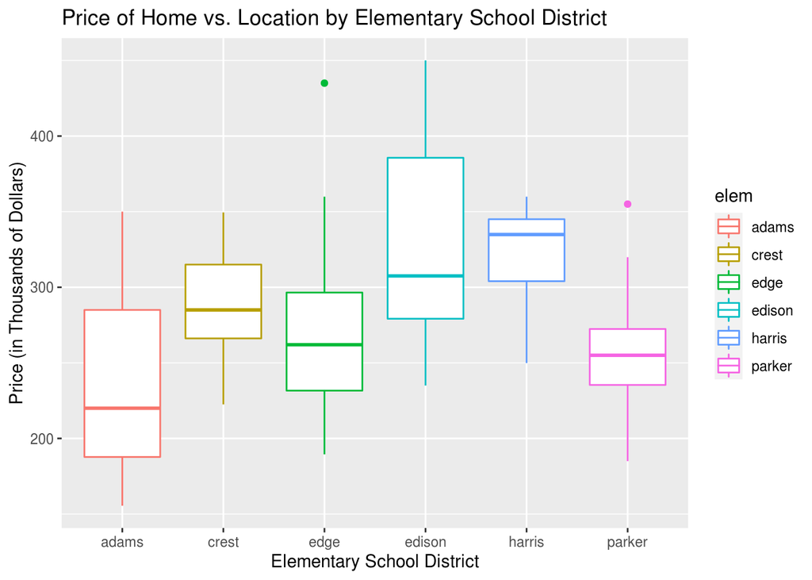

```r
ggplot(Housing, aes(x=elem, y=price, color=elem)) +
  geom_boxplot() +
  labs(y = "Price (in Thousands of Dollars)", x = "Elementary School District", title = "Price of Home vs. Location by Elementary School District")
```

After modeling price as a function of elementary school district, we decided it was significant as a predictor. The p-value is 0.001601 and the R-squared is 0.241. Houses near Edison and Harris Elementary are more expensive, they may be in a nicer area. Houses near Adams Elementary have a much lower average price. The other three elementary school districts fall somewhere in the middle, with pretty average prices.

- X1 = 1 if Crest, 0 if otherwise
- X2 = 1 if Edge, 0 if otherwise
- X3 = 1 if Edison, 0 if otherwise
- X4 = 1 if Harris, 0 if otherwise
- X5 = 1 if Parker, 0 if otherwise

$$\hat{Y} = {241.83} + 45.98 (X_1) + 27.92(X_2) + 92.05(X_3) + 77.27(X_4) + 15.61(X_5)$$

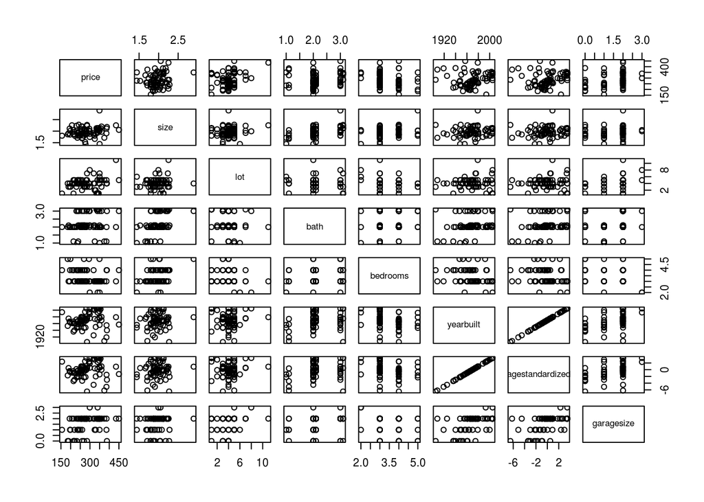

```r
#Looking at correlations between variables to see if there is anything we can immediately rule out.
pairs(Housing1.0[,2:9])
```

```r
cor(Housing1.0[,2:9])
```

```
##                      price       size         lot       bath   bedrooms
## price            1.0000000 0.19915793  0.23809143  0.1724495 -0.2850120
## size             0.1991579 1.00000000  0.03487068  0.4715328  0.2805644
## lot              0.2380914 0.03487068  1.00000000 -0.1788275 -0.1738811
## bath             0.1724495 0.47153278 -0.17882748  1.0000000  0.1791610
## bedrooms        -0.2850120 0.28056441 -0.17388112  0.1791610  1.0000000
## yearbuilt        0.1430698 0.17090118 -0.07653965  0.3346096 -0.2982876
## agestandardized  0.1430698 0.17090118 -0.07653965  0.3346096 -0.2982876
## garagesize       0.3539501 0.16741237  0.21082829  0.1975146 -0.3472314
##                   yearbuilt agestandardized garagesize
## price            0.14306983      0.14306983  0.3539501
## size             0.17090118      0.17090118  0.1674124
## lot             -0.07653965     -0.07653965  0.2108283
## bath             0.33460963      0.33460963  0.1975146
## bedrooms        -0.29828763     -0.29828763 -0.3472314
## yearbuilt        1.00000000      1.00000000  0.5088918
## agestandardized  1.00000000      1.00000000  0.5088918
## garagesize       0.50889176      0.50889176  1.0000000
```

Here, we are reminded that year built and age standardized contain the exact same information. Age standardized is a function of year built. We know we can exclude year built from our model because age standardized contains the same information, just streamlined, making our model easier to understand. Now, we review correlations to see which variables correlate the most with price. Most of the variables correlatation values are very close. The highest is garage size, followed by bedrooms. All of the variables have at least some correlation, so we are not ruling anything else out at this point.

### **Initial Model Building**

#### **Initial Model Building**

##### **Model 1:**

```r
mlr1 <- lm(data = Housing1.0, price ~ size + lot + bath + bedrooms + agestandardized + garagesize + elem + status)
summary(mlr1)
```

```
##
## Call:
## lm(formula = price ~ size + lot + bath + bedrooms + agestandardized +
##     garagesize + elem + status, data = Housing1.0)
##
## Residuals:
##    Min     1Q Median     3Q    Max
## -93.08 -34.10  -0.49  26.34  99.71
##
## Coefficients:
##                 Estimate Std. Error t value Pr(>|t|)
## (Intercept)      118.099     56.409   2.094  0.04046 *
## size              72.276     31.301   2.309  0.02434 *
## lot               10.563      3.691   2.862  0.00577 **
## bath               5.376     11.858   0.453  0.65191
## bedrooms         -11.670      9.894  -1.180  0.24275
## agestandardized    1.286      3.361   0.383  0.70330
## garagesize         7.666      9.549   0.803  0.42521
## elemcrest          1.063     34.442   0.031  0.97547
## elemedge           4.578     29.330   0.156  0.87647
## elemedison        84.899     31.251   2.717  0.00857 **
## elemharris        50.432     30.952   1.629  0.10839
## elemparker       -14.531     30.290  -0.480  0.63313
## statuspen        -19.054     16.663  -1.143  0.25730
## statussld        -37.081     14.082  -2.633  0.01070 *
## ---
## Signif. codes:  0 '***' 0.001 '**' 0.01 '*' 0.05 '.' 0.1 ' ' 1
##
## Residual standard error: 45.36 on 61 degrees of freedom
## Multiple R-squared:  0.5383, Adjusted R-squared:  0.4399
## F-statistic: 5.471 on 13 and 61 DF,  p-value: 1.975e-06
```

```r
vif(mlr1)
```

```
##                     GVIF Df GVIF^(1/(2*Df))
## size            1.607968  1        1.268057
## lot             1.330720  1        1.153568
## bath            1.663981  1        1.289954
## bedrooms        1.626144  1        1.275204
## agestandardized 2.136654  1        1.461730
## garagesize      1.869171  1        1.367176
## elem            2.620826  5        1.101143
## status          1.615332  2        1.127367
```

Reviewing our summary for our first model, we see that the residual standard error is 45.36, meaning the actual price of a home deviates, on average, 45,360 dollars from the predicted price on the regression line. That number isn’t horrible, but this is our first model, so we want to improve it. R-squared is 0.5383, meaning the predictors in our model can account for 53.83% of the variability in price. The p-value is much less than 0.5, so our model is definitely significant. As far as individual predictors, size, lot, elem = edison, and status = sld are all significant. Based on the vif, our model should do a decent job predicting. None of the variables seem to coordinate very much with other variables. This is good news.

```r
set.seed(1)
train <- sample(75, 60, replace = FALSE)
trainingdata <- Housing1.0[train,]
trainingdata
```

```
## # A tibble: 60 x 11
##       id price  size   lot  bath bedrooms yearbuilt agestandardized garagesize
##    <dbl> <dbl> <dbl> <dbl> <dbl>    <dbl>     <dbl>           <dbl>      <dbl>
##  1    20  277   1.44     3   2          3      1948            -2.2          2
##  2    28  330   1.89     2   2          3      1950            -2            1
##  3    43  197   1.85     3   2          4      1964            -0.6          1
##  4    67  270   2.05     3   2.1        3      1977             0.7          2
##  5    15  319   1.86     4   2          4      1925            -4.5          2
##  6    64  374.  1.71     5   1.1        3      1908            -6.2          2
##  7    73  215   2.04     1   1.1        4      1936            -3.4          0
##  8    46  190.  1.91     3   2.1        3      1975             0.5          0
##  9    44  282.  1.89     4   2          3      2005             3.5          2
## 10     5  156.  1.8      1   2          4      1994             2.4          1
## # … with 50 more rows, and 2 more variables: status <chr>, elem <chr>
```

```r
#creating training data to make a model with 80% of our data
training_price_model <- lm(data = trainingdata, price ~ size + lot + bath + bedrooms + agestandardized + garagesize + elem + status, family = binomial(link='logit'))
testdata <- Housing1.0[-train,]
testdata
```

```
## # A tibble: 15 x 11
##       id price  size   lot  bath bedrooms yearbuilt agestandardized garagesize
##    <dbl> <dbl> <dbl> <dbl> <dbl>    <dbl>     <dbl>           <dbl>      <dbl>
##  1     3  386   2.11     5   2          4      1955            -1.5          2
##  2     4  350   1.44     6   1          2      1956            -1.4          1
##  3     9  270.  1.92     4   2.1        4      1965            -0.5          2
##  4    13  265   1.88     4   2.1        3      1979             0.9          2
##  5    32  260.  1.71     4   2          4      1937            -3.3          0
##  6    37  235   1.71     5   1          3      1948            -2.2          1
##  7    38  256.  2.2      4   2.1        3      1966            -0.4          2
##  8    39  320.  1.92     7   2.1        3      2004             3.4          2
##  9    40  355   2.13     5   2          3      2003             3.3          2
## 10    47  340.  2.05     5   2          2      1993             2.3          3
## 11    54  285   2.27     3   3.1        4      1905            -6.5          0
## 12    60  336   2.13     1   3.1        3      2005             3.5          2
## 13    62  340   2.13     1   3.1        3      2005             3.5          2
## 14    74  435   2.25    11   2          3      1979             0.9          2
## 15    75  275.  1.86     4   2          4      1995             2.5          2
## # … with 2 more variables: status <chr>, elem <chr>
```

```r
#creating testing data from the other 20%
predictions <- predict(training_price_model, newdata = testdata)
#predicting the price of the test data using the model we built
predictions_df<- data.frame(predictions)
error <- (abs(predictions_df$predictions - testdata$price)/testdata$price)*100
#calculating how close we predicted to the actual price of those homes
error_df <- data.frame(error)
print(mean(error_df$error))
```

```
## [1] 16.5226
```

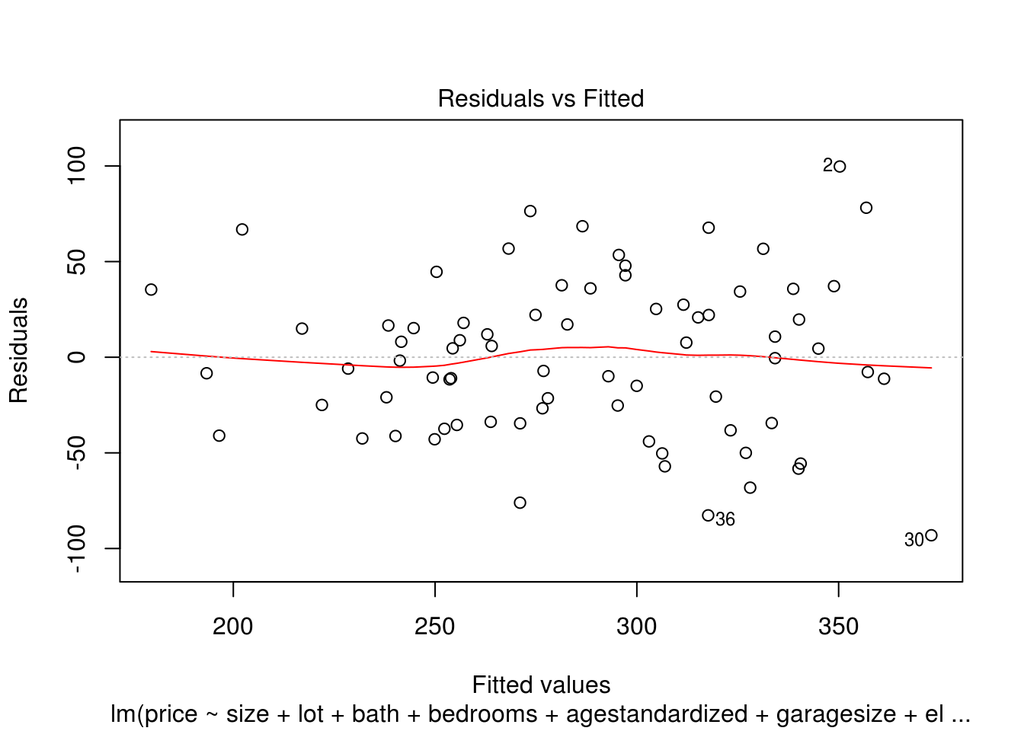

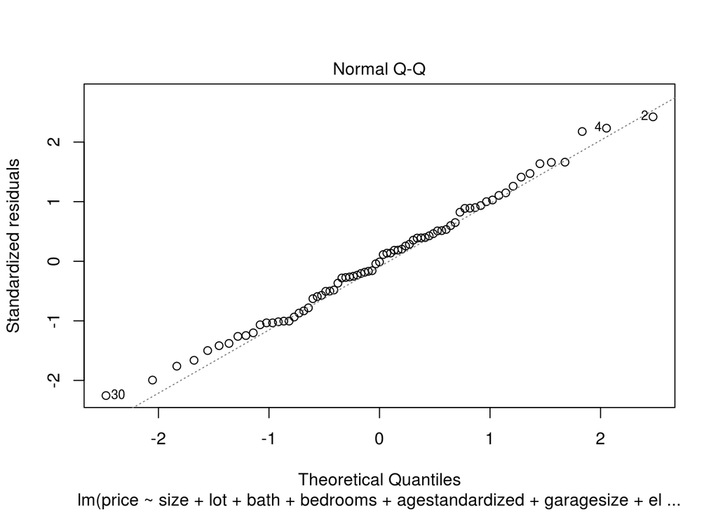

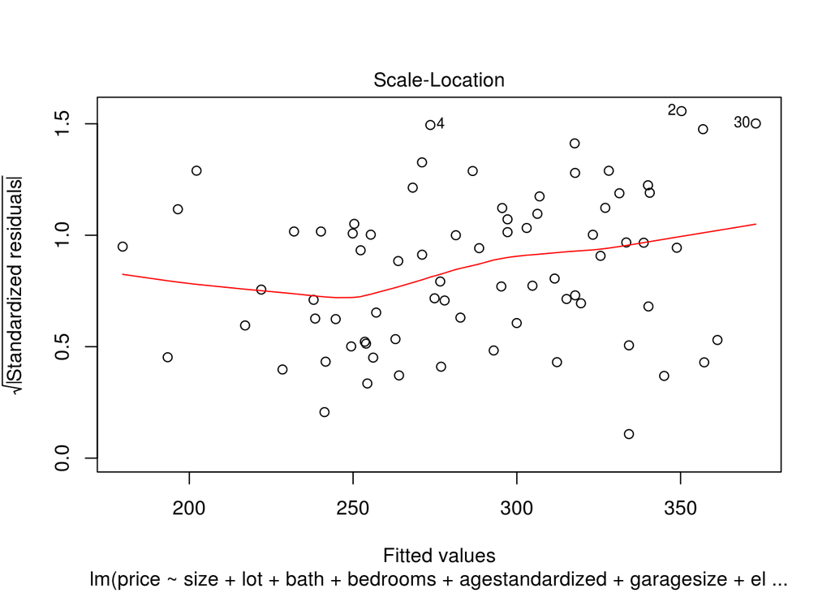

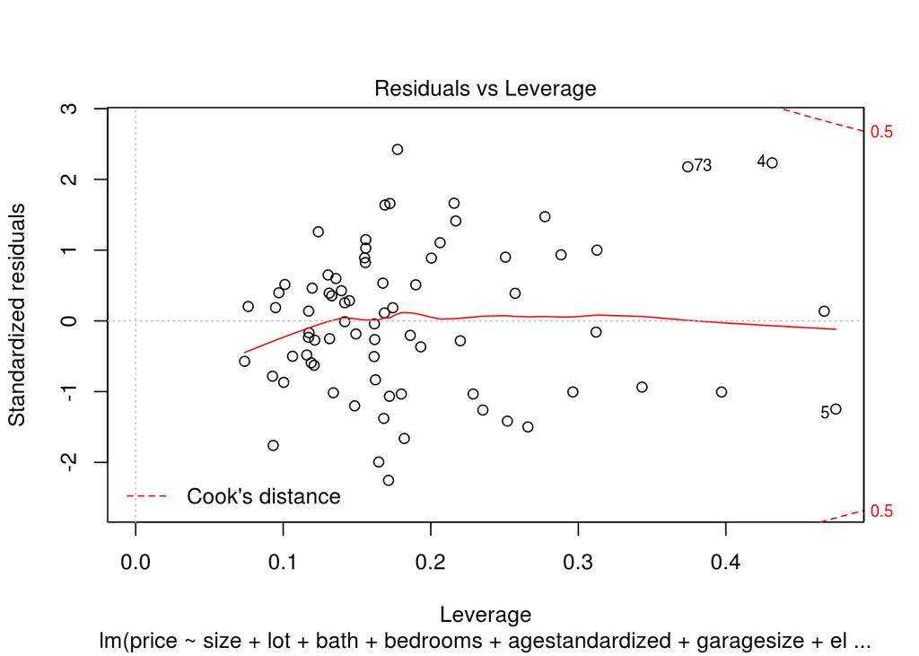

```r
plot(mlr1)
```

***

This shows a set of diagnostic plots for our first model. In the first plot, Residuals vs. Fitted, we are looking to see if the residuals have nonlinear patterns. Our model had no distinctive pattern present on this plot. The second plot, Normal QQ, tells us whether or not the residuals are normally distributed. If the dots follow a straight line, the distribution is normal. None of the points are especially concerning, they are fairly well fit to the line. On the Scale-Location plot, the residuals here look evenly spread, and the line is pretty horizontal. In the Residuals vs. Leverage plot we see that are the points are pretty well inside the Cook’s distance lines, so we conclude that there are no abnormally influential cases. We were unable to diagnose any particular issues, so we decided to try a few different combinations of predictors in order to minimize our residual standard error and improve our R-squared.

### **Model Modification**

#### **Model Modification**

##### **Model 2:**

```r
mlr2 <- lm(data = Housing1.0, price ~ size + bedrooms + lot + garagesize)
summary(mlr2)
```

```
##
## Call:
## lm(formula = price ~ size + bedrooms + lot + garagesize, data = Housing1.0)
##
## Residuals:
##     Min      1Q  Median      3Q     Max
## -116.47  -40.40  -12.62   38.40  160.09
##
## Coefficients:
##             Estimate Std. Error t value Pr(>|t|)
## (Intercept)  187.848     64.354   2.919  0.00472 **
## size          66.357     32.609   2.035  0.04564 *
## bedrooms     -23.001     10.841  -2.122  0.03740 *
## lot            5.296      3.991   1.327  0.18880
## garagesize    15.645      9.534   1.641  0.10529
## ---
## Signif. codes:  0 '***' 0.001 '**' 0.01 '*' 0.05 '.' 0.1 ' ' 1
##
## Residual standard error: 54.92 on 70 degrees of freedom
## Multiple R-squared:  0.2234, Adjusted R-squared:  0.179
## F-statistic: 5.033 on 4 and 70 DF,  p-value: 0.001268
```

```r
vif(mlr2)
```

```
##       size   bedrooms        lot garagesize
##   1.190514   1.331855   1.061257   1.271141
```

We decided on the predictors for this model by looking at the variables with the greatest correlation values with price. We decided on four because the predictors that came after the first four all had extremely close values for correlation with price. This model was immediately thrown out when compared to Model 1. It has a higher residual standard error, and a lower R-squared. The vifs are good, but not much better than Model 1.

##### **Model 3:**

```r
mlr3 <- lm(data = Housing1.0, price ~ size + lot + elem + status)
summary(mlr3)
```

```
##
## Call:
## lm(formula = price ~ size + lot + elem + status, data = Housing1.0)
##
## Residuals:
##     Min      1Q  Median      3Q     Max
## -90.344 -32.157   0.386  31.218 104.036
##
## Coefficients:
##             Estimate Std. Error t value Pr(>|t|)
## (Intercept)   87.486     53.320   1.641 0.105674
## size          78.387     26.289   2.982 0.004031 **
## lot           12.384      3.429   3.612 0.000593 ***
## elemcrest     -8.671     34.106  -0.254 0.800107
## elemedge       6.432     28.640   0.225 0.823019
## elemedison    82.415     30.213   2.728 0.008190 **
## elemharris    59.458     30.359   1.958 0.054465 .
## elemparker   -18.868     29.923  -0.631 0.530546
## statuspen    -19.134     16.583  -1.154 0.252792
## statussld    -46.863     13.028  -3.597 0.000622 ***
## ---
## Signif. codes:  0 '***' 0.001 '**' 0.01 '*' 0.05 '.' 0.1 ' ' 1
##
## Residual standard error: 45.56 on 65 degrees of freedom
## Multiple R-squared:  0.5036, Adjusted R-squared:  0.4349
## F-statistic: 7.328 on 9 and 65 DF,  p-value: 2.776e-07
```

```r
vif(mlr3)
```

```
##            GVIF Df GVIF^(1/(2*Df))
## size   1.124246  1        1.060305
## lot    1.138113  1        1.066824
## elem   1.507558  5        1.041903
## status 1.294024  2        1.066561
```

This model uses all of the significant predictors from Model 1. Model 3 and Model 1 are very comparable. Their values for residual standard error and R-squared are extremely close, but Model 1 is slightly better.

#### **Model 4:**

```r
mlr4 <- lm(data = Housing1.0, price ~ bedrooms*size + lot + elem + status)
summary(mlr4)
```

```
##
## Call:
## lm(formula = price ~ bedrooms * size + lot + elem + status, data = Housing1.0)
##
## Residuals:
##     Min      1Q  Median      3Q     Max
## -91.856 -29.901   1.543  24.468 112.486
##
## Coefficients:
##               Estimate Std. Error t value Pr(>|t|)
## (Intercept)   109.8902   222.7685   0.493  0.62352
## bedrooms      -13.0635    61.3610  -0.213  0.83210
## size           93.9495   117.0232   0.803  0.42509
## lot            10.7506     3.5354   3.041  0.00343 **
## elemcrest       0.9338    34.4564   0.027  0.97846
## elemedge       11.4234    30.1020   0.379  0.70560
## elemedison     85.8071    30.5665   2.807  0.00664 **
## elemharris     58.1569    31.7263   1.833  0.07152 .
## elemparker    -11.5883    31.7102  -0.365  0.71600
## statuspen     -20.5946    16.6272  -1.239  0.22008
## statussld     -43.4600    13.5156  -3.216  0.00206 **
## bedrooms:size  -1.1191    30.4638  -0.037  0.97081
## ---
## Signif. codes:  0 '***' 0.001 '**' 0.01 '*' 0.05 '.' 0.1 ' ' 1
##
## Residual standard error: 45.23 on 63 degrees of freedom
## Multiple R-squared:  0.5259, Adjusted R-squared:  0.4431
## F-statistic: 6.353 on 11 and 63 DF,  p-value: 5.961e-07
```

```r
vif(mlr4)
```

```
##                     GVIF Df GVIF^(1/(2*Df))
## bedrooms       62.914203  1        7.931847
## size           22.605776  1        4.754553
## lot             1.227839  1        1.108079
## elem            2.135828  5        1.078839
## status          1.443944  2        1.096194
## bedrooms:size 102.620359  1       10.130171
```

Model 4 is the closest to Model 1. The residual standard error is slightly less. The R-squared is also slightly less, but the adjusted R-squared is slightly higher. We used an interaction between bedroom and size because we thought that logically they would have to depend on each other. More bedrooms = bigger house.

```r
training_price_model4 <- lm(data = trainingdata, price ~ bedrooms*size + lot + elem + status)

predictions4 <- predict(training_price_model4, newdata = testdata)
predictions_df4 <- data.frame(predictions4)
error4 <- (abs(predictions_df4$predictions4 - testdata$price)/testdata$price)*100
error_df4 <- data.frame(error4)
print(mean(error_df4$error4))
```

```
## [1] 16.63644
```

Based on the R-squared for this model, we thought it had a chance at being a better predictor than Model 1. We used the same training and test data to see how this model did at predicting. The average prediction error for this model was slightly worse, at 16.6%

##### **Model 5**

```r
mlr5 <- lm(data = Housing1.0, price ~ size*bath + lot + elem + status + bedrooms + garagesize^2)
summary(mlr5)
```

```
##
## Call:
## lm(formula = price ~ size * bath + lot + elem + status + bedrooms +
##     garagesize^2, data = Housing1.0)
##
## Residuals:
##     Min      1Q  Median      3Q     Max
## -88.788 -30.965  -0.675  26.555 101.422
##
## Coefficients:
##             Estimate Std. Error t value Pr(>|t|)
## (Intercept)  268.508    213.563   1.257  0.21344
## size         -10.471    117.851  -0.089  0.92949
## bath         -62.067     93.988  -0.660  0.51150
## lot           10.538      3.639   2.896  0.00524 **
## elemcrest      3.379     34.487   0.098  0.92228
## elemedge      13.261     31.653   0.419  0.67673
## elemedison    86.161     30.755   2.802  0.00681 **
## elemharris    58.685     32.505   1.805  0.07594 .
## elemparker    -5.050     32.594  -0.155  0.87738
## statuspen    -16.707     16.829  -0.993  0.32474
## statussld    -34.292     14.626  -2.345  0.02232 *
## bedrooms     -12.781      9.473  -1.349  0.18228
## garagesize     8.890      8.914   0.997  0.32257
## size:bath     35.145     47.844   0.735  0.46541
## ---
## Signif. codes:  0 '***' 0.001 '**' 0.01 '*' 0.05 '.' 0.1 ' ' 1
##
## Residual standard error: 45.22 on 61 degrees of freedom
## Multiple R-squared:  0.5412, Adjusted R-squared:  0.4435
## F-statistic: 5.536 on 13 and 61 DF,  p-value: 1.67e-06
```

```r
vif(mlr5)
```

```
##                  GVIF Df GVIF^(1/(2*Df))
## size        22.940253  1        4.789598
## bath       105.206117  1       10.257003
## lot          1.301331  1        1.140759
## elem         2.912239  5        1.112814
## status       1.744377  2        1.149238
## bedrooms     1.500430  1        1.224920
## garagesize   1.639408  1        1.280394
## size:bath  168.056492  1       12.963660
```

```r
training_price_model5 <- lm(data = trainingdata, price ~ size*bath + lot + elem + status + bedrooms + garagesize^2)

predictions5 <- predict(training_price_model5, newdata = testdata)
predictions_df5 <- data.frame(predictions5)
error5 <- (abs(predictions_df5$predictions5 - testdata$price)/testdata$price)*100
error_df5 <- data.frame(error5)
print(mean(error_df5$error5))
```

```
## [1] 15.73939
```

We then used our model to predict, using the same training and test data as before. The average prediction error was 15.74%. This model gave the best predictions so far.

##### **Model 6**

```r
mlr6 <- lm(data = Housing1.0, price ~ size + bath + lot + elem  + status + log(bedrooms) + garagesize^2)
summary(mlr6)
```

```
##
## Call:
## lm(formula = price ~ size + bath + lot + elem + status + log(bedrooms) +
##     garagesize^2, data = Housing1.0)
##
## Residuals:
##     Min      1Q  Median      3Q     Max
## -90.791 -33.767  -0.431  25.130 101.496
##
## Coefficients:
##               Estimate Std. Error t value Pr(>|t|)
## (Intercept)    130.864     58.318   2.244  0.02841 *
## size            74.591     30.939   2.411  0.01889 *
## bath             6.278     11.354   0.553  0.58232
## lot             10.074      3.615   2.786  0.00706 **
## elemcrest        3.537     34.237   0.103  0.91805
## elemedge         6.828     29.184   0.234  0.81579
## elemedison      84.721     30.162   2.809  0.00664 **
## elemharris      53.396     30.616   1.744  0.08611 .
## elemparker     -11.600     30.130  -0.385  0.70156
## statuspen      -19.836     16.500  -1.202  0.23388
## statussld      -37.201     13.911  -2.674  0.00956 **
## log(bedrooms)  -49.993     32.600  -1.534  0.13023
## garagesize       8.506      8.824   0.964  0.33884
## ---
## Signif. codes:  0 '***' 0.001 '**' 0.01 '*' 0.05 '.' 0.1 ' ' 1
##
## Residual standard error: 44.86 on 62 degrees of freedom
## Multiple R-squared:  0.541,  Adjusted R-squared:  0.4522
## F-statistic:  6.09 on 12 and 62 DF,  p-value: 6.571e-07
```

```r
training_price_model6 <- lm(data = trainingdata, price ~ size + bath + lot + elem + status + log(bedrooms) + garagesize^2)
#using same training/test data to see how this model does at predicting
predictions6 <- predict(training_price_model6, newdata = testdata)
predictions_df6 <- data.frame(predictions6)
error6 <- (abs(predictions_df6$predictions6 - testdata$price)/testdata$price)*100
error_df6 <- data.frame(error6)
print(mean(error_df6$error6))
```

```
## [1] 15.56249
```

We once again used our new model to predict the same test data. As expected, this model outperformed the others, and gave us a prediction error of 15.56%.

### **Conclusions**

#### **Conclusions**

```r
mlr6 <- lm(data = Housing1.0, price ~ size + bath + lot + elem  + status + log(bedrooms) + garagesize^2)
summary(mlr6)
```

```
##
## Call:
## lm(formula = price ~ size + bath + lot + elem + status + log(bedrooms) +
##     garagesize^2, data = Housing1.0)
##
## Residuals:
##     Min      1Q  Median      3Q     Max
## -90.791 -33.767  -0.431  25.130 101.496
##
## Coefficients:
##               Estimate Std. Error t value Pr(>|t|)
## (Intercept)    130.864     58.318   2.244  0.02841 *
## size            74.591     30.939   2.411  0.01889 *
## bath             6.278     11.354   0.553  0.58232
## lot             10.074      3.615   2.786  0.00706 **
## elemcrest        3.537     34.237   0.103  0.91805
## elemedge         6.828     29.184   0.234  0.81579
## elemedison      84.721     30.162   2.809  0.00664 **
## elemharris      53.396     30.616   1.744  0.08611 .
## elemparker     -11.600     30.130  -0.385  0.70156
## statuspen      -19.836     16.500  -1.202  0.23388
## statussld      -37.201     13.911  -2.674  0.00956 **
## log(bedrooms)  -49.993     32.600  -1.534  0.13023
## garagesize       8.506      8.824   0.964  0.33884
## ---
## Signif. codes:  0 '***' 0.001 '**' 0.01 '*' 0.05 '.' 0.1 ' ' 1
##
## Residual standard error: 44.86 on 62 degrees of freedom
## Multiple R-squared:  0.541,  Adjusted R-squared:  0.4522
## F-statistic:  6.09 on 12 and 62 DF,  p-value: 6.571e-07
```

```r
vif(mlr6)
```

```
##                   GVIF Df GVIF^(1/(2*Df))
## size          1.606233  1        1.267372
## bath          1.559723  1        1.248889
## lot           1.305217  1        1.142461
## elem          2.035014  5        1.073635
## status        1.614506  2        1.127223
## log(bedrooms) 1.519874  1        1.232832
## garagesize    1.632204  1        1.277577
```

This is our final model. It has a residual standard error of 44.86, the lowest of any of the models we tested. This means that on average, the price of a home deviates from the regression line by $44,860. The R-squared is 0.541, meaning that the predictors in this model account for 54.1 of the variation in home price. All of the VIFs are great. There is only one above 2, and its only 2.04. This means the predictors in this model hardly correlate with one another.

This is the equation for our model:

- X1 = 1 if elem = crest, 0 if otherwise
- X2 = 1 if elem = edge, 0 if otherwise
- X3 = 1 if elem = edison, 0 if otherwise
- X4 = 1 if elem = harris, 0 if otherwise
- X5 = 1 if elem = parker, 0 if otherwise
- X6 = 1 if status = pending sale, 0 if otherwise
- X7 = 1 if status = sold, 0 if otherwise

$$\hat{Y} = {130.864} + 74.591(Size)+6.278(Bath)+10.074(Lot)+3.537(X_1)+6.828(X_2)+84.721(X_3)+53.396(X_4)-11.600(X_5)-19.836(X_6)-37.201(X_7)-49.993(log(Bedrooms))+8.506(Garage Size)$$

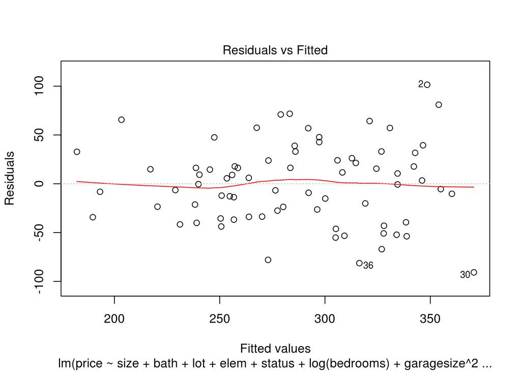

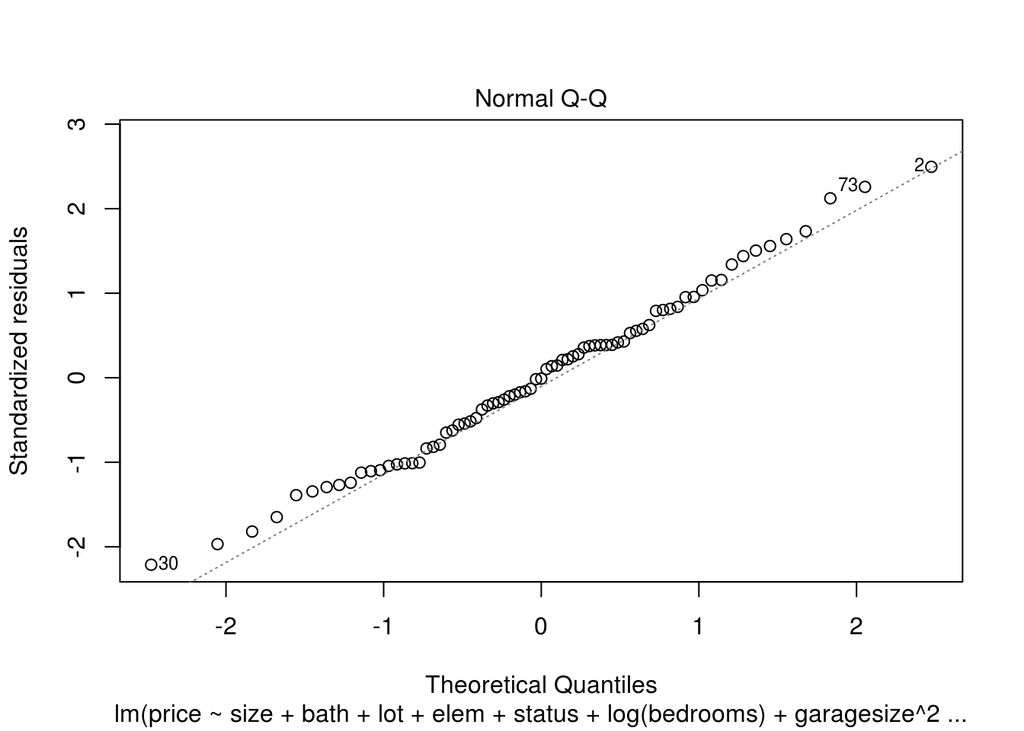

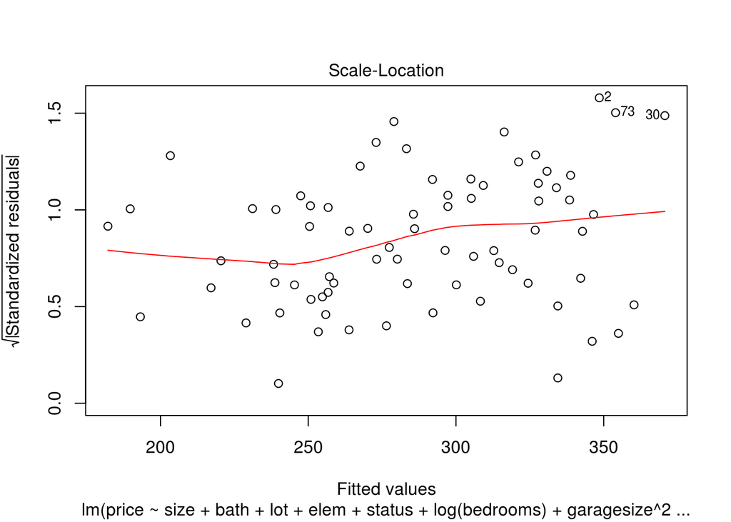

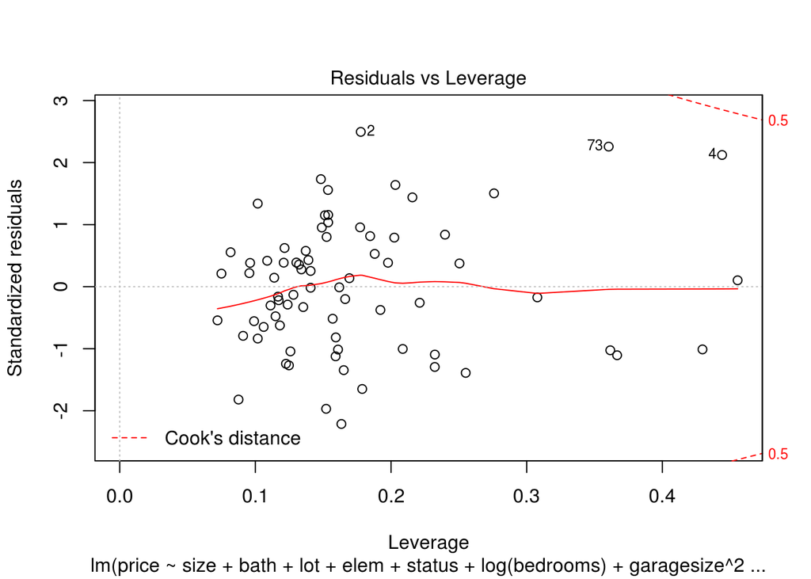

```r
plot(mlr6)
```

In the Residuals vs. Fitted values plot, we see a horizontal line, surrounded by points with no distinctive pattern. This means the residuals do not have nonlinear patterns. On the Normal QQ plot, we see our points generally fit along the line pretty well. None of the points look concerning. On our Scale-Location plot, we see a horizontal line with randomly spready residuals. The horizontal line shows that the average magnitude of the standardized residuals does not vary much as our model fits more values. The equal spread of the points around this line means constant variance. In the Residuals vs. Leverage plot, we do not see any cases with extremely high influence, as all the points are within the Cook’s distance lines. We do however, see that #4 is close. This was also the case in our original model.  
***

```r
#95% confidence intervals for the coefficients
confint(mlr6)
```

```
##                     2.5 %     97.5 %
## (Intercept)     14.288718 247.439815
## size            12.744289 136.437218
## bath           -16.418777  28.973902
## lot              2.847100  17.300913
## elemcrest      -64.901953  71.975802
## elemedge       -51.510616  65.166379
## elemedison      24.428539 145.012693
## elemharris      -7.804615 114.595769
## elemparker     -71.828214  48.628625
## statuspen      -52.819690  13.147867
## statussld      -65.007526  -9.393875
## log(bedrooms) -115.158586  15.173515
## garagesize      -9.133949  26.145702
```

```r
set.seed(1)
train0 <- sample(75, 74, replace = FALSE)
trainingdata0 <- Housing1.0[train0,]
#creating training data that consists of all but 1 house
training_price_model0 <- lm(data = trainingdata, price ~ size + bath + lot + elem  + status + log(bedrooms) + garagesize^2)

testdata0 <- Housing1.0[-train0,]
#creating test data that is just the 1 house excluded from the training data
predictions0 <- predict(training_price_model0, newdata = testdata0)
predictions_df0<- data.frame(predictions0)
error0 <- (abs(predictions_df0$predictions0 - testdata0$price)/testdata0$price)*100
error_df0 <- data.frame(error0)
print(mean(error_df0$error0))
```

```
## [1] 2.403992
```

```r
#calculating the difference between predicted vs. actual, then dividing by the actual value to get an prediction error percentage
```

```r
hypothetical_home <- data.frame("size" = 1.800, "lot" = 3, "bath" = 2, "bedrooms" = 3, "elem" = "edison", "status" = "sld", "garagesize" = 1)
#creating hypothetical values for a house
#doing a 95% prediction interval for said house
predict(mlr6, newdata  = hypothetical_home, interval = "predict")
```

```
##        fit      lwr      upr
## 1 309.0081 214.1491 403.8672
```

```r
#doing a 95% confidence interval for said house
predict(mlr6, newdata  = hypothetical_home, interval = "confidence")
```

```
##        fit      lwr      upr
## 1 309.0081 278.0927 339.9236
```

The 95% prediction interval says that we are 95% certain that the price of the hypothetical home would be between 214,149 and 403,867 dollars. The confidence interval says that it is 95% certain that the mean of prediction values is between 278,093 and 339,924 dollars.